# PA1_template

SI

27 October 2017

*Loading and preprocessing the data*

*Show any code that is needed to*

*1. Load the data (i.e. read.csv())*

```r
activity <- read.csv("activity.csv", header = TRUE)
```

*2 Process/transform the data (if necessary) into a format suitable for your analysis*

```r
library(plyr)
library(dplyr)
library(tidyr)
library(knitr)
summary(activity)
```

```
##      steps                date          interval
##  Min.   :  0.00   2012-10-01:  288   Min.   :   0.0
##  1st Qu.:  0.00   2012-10-02:  288   1st Qu.: 588.8
##  Median :  0.00   2012-10-03:  288   Median :1177.5
##  Mean   : 37.38   2012-10-04:  288   Mean   :1177.5
##  3rd Qu.: 12.00   2012-10-05:  288   3rd Qu.:1766.2
##  Max.   :806.00   2012-10-06:  288   Max.   :2355.0
##  NA's   :2304     (Other)   :15840
```

*What is mean total number of steps taken per day?*

*For this part of the assignment, you can ignore the missing values in the* *dataset.*

We take out missing values (NAs in the ‘steps’ variable) and assign it the a new variable (‘activityCleaned’)

```r
activityCleaned <- na.omit(activity)
```

*1. Calculate the total number of steps taken per day*

```r
SumStepsperDay <- group_by(activityCleaned, date) %>% summarise(sum(steps))
SumStepsperDay
```

```
##   sum(steps)
## 1     570608
```

*2. Make a histogram of the total number of steps taken each day*

[figure not shown]

```r
hist(SumStepsperDay$`sum(steps)`, freq = TRUE, main = "Histogram for total steps per each day", xlab = "Total no of steps in a day", ylab = "Frequency (no of days with a total no of steps taken)", plot = TRUE)
```

*3. Calculate and report the mean and median of the total number of steps taken per day*

```r
StepsperDayOnly <- SumStepsperDay$`sum(steps)`
mean(StepsperDayOnly)
```

```
## [1] 570608
```

```r
median(StepsperDayOnly)
```

```
## [1] 570608
```

*What is the average daily activity pattern?*

*Make a time series plot (i.e. type = “l”) of the 5-minute interval (x-axis)* *and the average number of steps taken, averaged across all days (y-axis)*

[figure not shown]

```r
IntStepsMean <- activityCleaned %>% group_by(interval) %>% summarize(mean(steps))
plot(IntStepsMean, type = "l")
```

*Which 5-minute interval, on average across all the days in the dataset,* *contains the maximum number of steps?*

```r
IntStepsMean[which.max(IntStepsMean$`mean(steps)`),]
```

[output not shown]

*Imputing missing values*

*Note that there are a number of days/intervals where there are missing values* *(coded as NA). The presence of missing days may introduce bias into some* *calculations or summaries of the data.*

*1.Calculate and report the total number of missing values in the dataset (i.e.* *the total number of rows with NAs)*

We calculate the number of NAs with the helps of is.na function, assign the result to a variable called ‘activityNAs’ (in case the value is needed further) and print this vaiable value (2304) in the same line with the help of print function.

```r
print(activityNAs <- sum(is.na(activity$steps)))
```

```
## [1] 2304
```

*2. Devise a strategy for filling in all of the missing values in the dataset.* *The strategy does not need to be sophisticated. For example, you could use* *the mean/median for that day, or the mean for that 5-minute interval, etc.*

We will use the specific 5 mintue interval steps mean calculated across all the days and replace the NA values of the steps with this mean.

*3. Create a new dataset that is equal to the original dataset but with the* *missing data filled in.*

We have read the file into w new variable called activityUpdated and then rewritten this variable by replacing the NA values with the mean of the steps across all days for that 5 minute interval.

```r
activityUpdated <- read.csv("activity.csv", header = TRUE)
i <- 1
repeat {
  if (is.na(activityUpdated[i, which(colnames(activityUpdated) == "steps")]))
        {
          activityUpdated[i, which(colnames(activityUpdated) == "steps")] <-
            filter(activityUpdated, interval == activityUpdated[i,
            which(colnames(activityUpdated) == "interval")]) %>%
              summarise(mean(steps, na.rm = TRUE))
        }
  i <- i+1
  if (i > nrow(activityUpdated)) break
}
```

*4. Make a histogram of the total number of steps taken each day and Calculate* *and report the mean and median total number of steps taken per day. Do these* *values differ from the estimates from the first part of the assignment? What* *is the impact of imputing missing data on the estimates of the total daily* *number of steps?*

[figure not shown]

```r
SumStepsperDayUpdated <- group_by(activityUpdated, date) %>% summarise(sum(steps))
hist(SumStepsperDayUpdated$`sum(steps)`, freq = TRUE, main = "Histogram for total steps per each day", xlab = "Total no of steps in a day", ylab = "Frequency (no of days with a total no of steps taken)", plot = TRUE)
```

```r
StepsperDayOnly2 <- SumStepsperDayUpdated$`sum(steps)`
mean(StepsperDayOnly2)
```

```
## [1] 656737.5
```

```r
median(StepsperDayOnly2)
```

```
## [1] 656737.5
```

*Are there differences in activity patterns between weekdays and weekends?*

*For this part the weekdays() function may be of some help here. Use the* *dataset with the filled-in missing values for this part.*

We create a new column using mutate in order to obtain days of the week with the help of the weekdays() function and then a separate column based on the previous were we include weekend vs weekday labels.

```r
activityUpdatedWEEK <- mutate(activityUpdated, DayInTheWeek = weekdays(as.Date(date)))
activityUpdatedWEEK$PartOfWeeK <- ifelse(activityUpdatedWEEK$DayInTheWeek == "Saturday" | activityUpdatedWEEK$DayInTheWeek == "Sunday", "Weekend", "Weekday")
activityUpdatedWEEK$PartOfWeeK <- factor(activityUpdatedWEEK$PartOfWeeK)
```

*2. Make a panel plot containing a time series plot (i.e. type = “l”) of the* *5-minute interval (x-axis) and the average number of steps taken, averaged* *across all weekday days or weekend days (y-axis). See the README file in the* *GitHub repository to see an example of what this plot should look like using* *simulated data.*

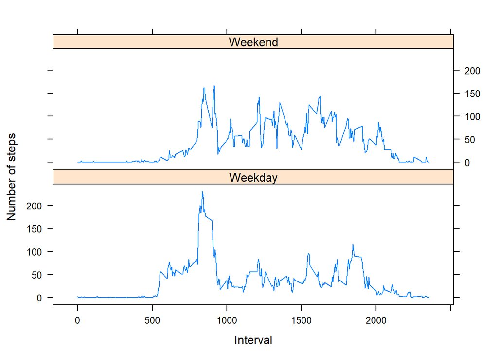

```r
library(lattice)
groupedByIntervalWeekDay <- ddply(activityUpdatedWEEK, ~interval + PartOfWeeK, summarise,
    mean = mean(steps))
groupedByIntervalWeekDay$interval <- as.numeric(as.character(groupedByIntervalWeekDay$interval))
xyplot(mean ~ interval | PartOfWeeK, groupedByIntervalWeekDay, type = "l",
    layout = c(1, 2), xlab = "Interval", ylab = "Number of steps")
```